# Extensions to the Grammar of Graphics

## Position functions

Function `position_nudge()` from package ‘ggplot2’ simply applies the nudge, or *x* and *y* shift based directly on the values passed to its parameters `x` and `y`. A new variation on simple nudge is provided by function `position_nudge_to()`.

Two new position functions supporting advanced nudging are made available by package ‘ggpmisc’. While `position_nudge()` implements shifts along $x$ and $y$ axes that are the same for every observation, the new functions compute the direction of the nudging specifically for each observation.

One can think of this approach as nudging away from a focal point, a line or a curve. It is deterministic, while repulsion is aleatory. Advanced nudging works very well, but only for some patterns of observations and may require manual adjustment of positions, repulsion is more generally applicable.

All the new position functions save the original coordinates to allow linking the nudged objects, usually text labels, to be linked to the original position. This is currently only supported by `geom_linked_text()`, but they may be also supported by ‘ggrepel’ in the future.

### position_nudge_keep()

`position_nudge_keep()` (and `position_nudge_center()` With the default `direction = "none"`) behaves as `ggplot2::position_nudge()` but saves the original coordinates. Currently the saved original coordinates are used only by `geom_linked_text()` as shown in the corresponding section above.

```r
set.seed(84532)
df <- data.frame(
  x = rnorm(10),
  y = rnorm(10, 2, 2),
  l = letters[1:10]
)
```

Here we keep the default justification, with text centred on its location.

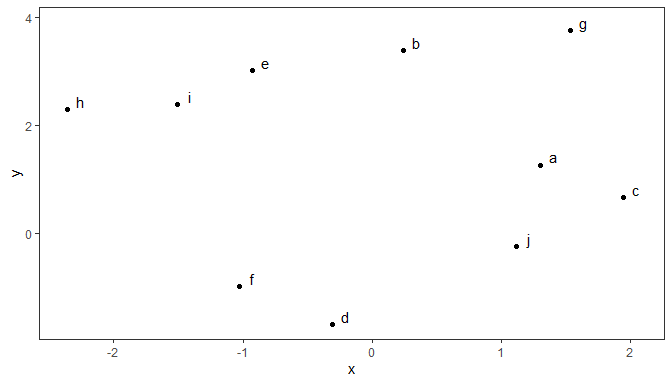

```r
ggplot(df, aes(x, y, label = l)) +
  geom_point() +
  geom_text(position = position_nudge_keep(x = 0.1, y = 0.15))
```

When using `geom_linked_text()` we need to change the default justification.

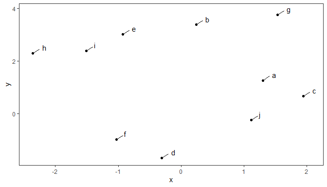

```r
ggplot(df, aes(x, y, label = l)) +
  geom_point() +
  geom_linked_text(position = position_nudge_keep(x = 0.1, y = 0.15),
                   hjust = -0.8, vjust = 0.2)
```

As this is also the default position function of this geometry, the code below is equivalent.

```r
ggplot(df, aes(x, y, label = l)) +
  geom_point() +
  geom_linked_text(nudge_x = 0.1, nudge_y = 0.15, hjust = -0.8, vjust = 0.2)
```

### position_nudge_to()

Function `position_nudge_to()` differs from `ggplot2::position_nudge()` in that the coordinates of the new positions are supplied directly rather than as a displacement.

```r
set.seed(84532)
df <- data.frame(
  x = rnorm(8),
  y = rnorm(8, 2, 2),
  l = letters[1:8]
)
```

We here the pass a vector of length one as argument for `y`, but `x` and `y` also accept vectors of the same length as rows has `data`. In other words, it allows manual positioning of text and labels.

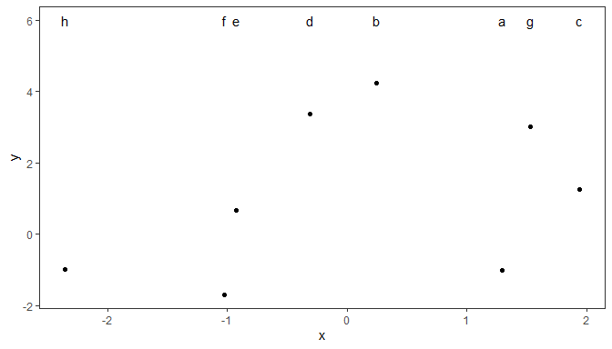

```r
ggplot(df, aes(x, y, label = l)) +
  geom_point() +
  geom_text(position = position_nudge_to(y = 6))
```

### position_nudge_center()

Function `position_nudge_center()` can nudge radially away from a focal point if both `x` and `y` are passed as arguments, or towards opposite sides of a boundary line if only one of `x` or `y` is passed an argument. By default, the “center” is the centroid computed using `mean()`, but other functions or numeric values can be passed to override it.

```r
set.seed(84532)
df <- data.frame(
  x = rnorm(20),
  y = rnorm(20, 2, 2),
  l = sample(letters[1:6], 20, replace = TRUE)
)
```

When using one of the directions `"split"` or `"radial"` by default a centroid computed with `mean()` is used as focal point. If the direction is `"split"` then only the sign of `x` and/or `y` are reversed to the left and below the focal point, respectively.

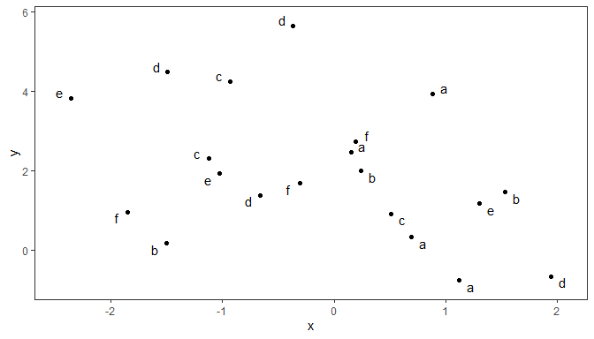

```r
ggplot(df, aes(x, y, label = l)) +
  geom_point() +
  geom_text(position = position_nudge_center(x = 0.1,
                                             y = 0.15,
                                             direction = "split"))
```

By default `x` and `y` take a value of zero.

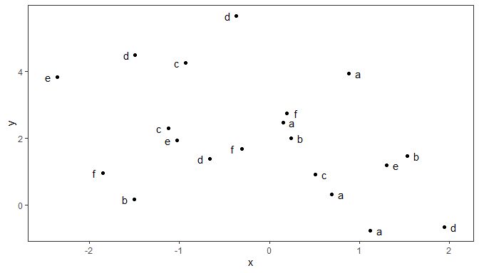

```r
ggplot(df, aes(x, y, label = l)) +
  geom_point() +
  geom_text(position = position_nudge_center(x = 0.1,
                                             direction = "split"))
```

We can override the default center coordinates by passing numeric values to `center_x` and/or `center_y`.

```r
ggplot(df, aes(x, y, label = l)) +
  geom_point() +
  geom_text(position = position_nudge_center(x = 0.1,
                                             center_x = 1,
                                             direction = "split"))
```

We can override the default center coordinates computed with `mean()` by passing as argument a different function.

```r
ggplot(df, aes(x, y, label = l)) +
  geom_point() +
  geom_text(position = position_nudge_center(x = 0.1,
                                             center_x = median,
                                             direction = "split"))
```

Direction `"radial"` applies nudge radially away from the focal point.

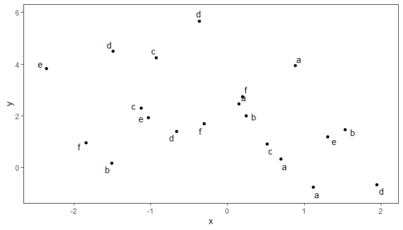

```r
ggplot(df, aes(x, y, label = l)) +
  geom_point() +
  geom_text(position = position_nudge_center(x = 0.1,
                                             y = 0.3,
                                             direction = "radial"))
```

### position_nudge_line()

Function `position_nudge_line()` nudges away from a line, which can be a user supplied straight line as well as a smooth spline or a polynomial fitted to the observations themselves. The nudging is away and perpendicular to the local slope of the straight or curved line. It relies on the same assumptions as linear regression, assuming that *x* values are not subject to error. This in most cases prevents labels from overlaping a curve fitted to the data, even if not exactly based on the same model fit. When observations are sparse, this may be enough to obtain a nice arrangement of data labels.

```r
set.seed(16532)
df <- data.frame(
  x = -10:10,
  y = (-10:10)^2,
  yy = (-10:10)^2 + rnorm(21, 0, 4),
  yyy = (-10:10) + rnorm(21, 0, 4),
  l = letters[1:21]
)
```

The first, simple example shows that `position_nudge_line()` has shifted the direction of the nudging based on the alignment of the observations along a line. One could, of course, have in this case passed suitable values as arguments to *x* and *y* using `position_nudge()` from package ‘ggplot2’.

Function `position_nudge_line()` will work without change irrespective of the slope or intercept along which the observations fall.

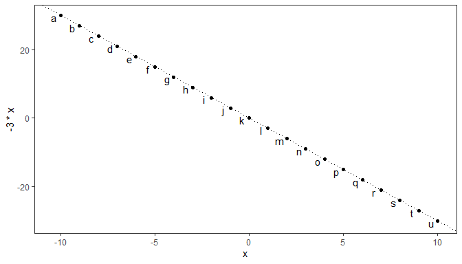

```r
ggplot(df, aes(x, -3 * x, label = l)) +
  geom_point() +
  geom_abline(intercept = 0, slope = -3, linetype = "dotted") +
  geom_text(position = position_nudge_line(x = -0.5, y = -0.8))
```

With observations with high variation in *y*, a linear model fit may need to be used.

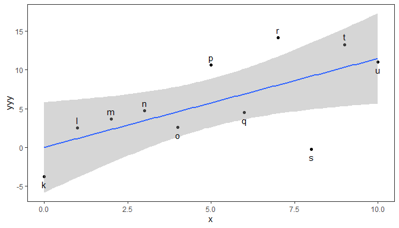

```r
ggplot(subset(df, x >= 0), aes(x, yyy)) +
  geom_point() +
  stat_smooth(method = "lm", formula = y ~ x) +
  geom_text(aes(label = l),
            vjust = "center", hjust = "center",
            position = position_nudge_line(x = 0, y = 1.2,
                                           method = "lm", formula = y ~ x,
                                           direction = "split"))
```

With lower variation in *y*, we can pass to `line_nudge` a multiplier to keep labels outside of the confidence band.

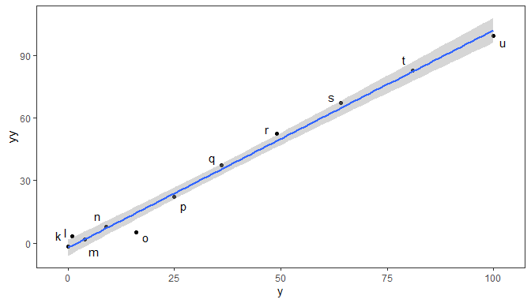

```r
ggplot(subset(df, x >= 0), aes(y, yy)) +
  geom_point() +
  stat_smooth(method = "lm", formula = y ~ x) +
  geom_text(aes(label = l),
            position = position_nudge_line(method = "lm",
                                           x = 3, y = 3,
                                           line_nudge = 2.8,
                                           direction = "split"))
```

If we want the nudging based on an arbitrary straight line not computed from `data`, we can pass the intercept and slope in a numeric vector of length two as an argument to parameter `abline`.

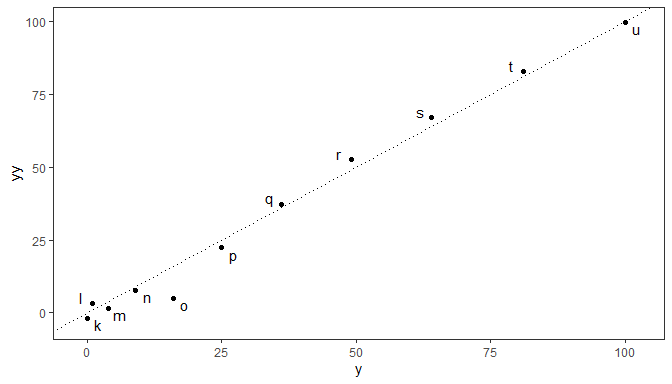

```r
ggplot(subset(df, x >= 0), aes(y, yy)) +
  geom_point() +
  geom_abline(intercept = 0, slope = 1, linetype = "dotted") +
  geom_text(aes(label = l),
            position = position_nudge_line(abline = c(0, 1),
                                           x = 3, y = 3,
                                           direction = "split"))
```

With observations that follow exactly a simple curve the defaults work well to automate the nudging of individual data labels away from the implicit curve. Positive values as arguments to `x` and `y` correspond to above and inside the curve. One could, of course, pass also in this case suitable values as arguments to *x* and *y* using `position_nudge()` from package ‘ggplot2’, but these arguments would need to be vectors with different *nudge* values for each observation.

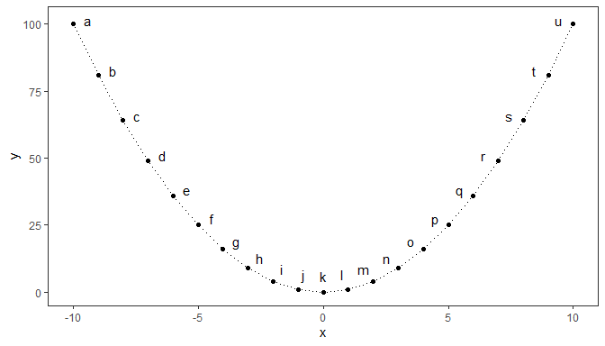

```r
ggplot(df, aes(x, y, label = l)) +
  geom_point() +
  geom_line(linetype = "dotted") +
  geom_text(position = position_nudge_line(x = 0.6, y = 6))
```

Negative values passed as arguments to `x` and `y` correspond to labels below and outside the curve.

```r
ggplot(df, aes(x, y, label = l)) +
  geom_point() +
  geom_line(linetype = "dotted") +
  geom_text(position = position_nudge_line(x = -0.6, y = -6))
```

When the observations include random variation along *y*, it is important that the smoother used for the line added to a plot and that passed to `position_nudge_line()` are similar. By default `stat_smooth()` uses `"loess"` and `position_nudge_line()` with method `"spline"`, `smooth.sline()`, which are a good enough match.

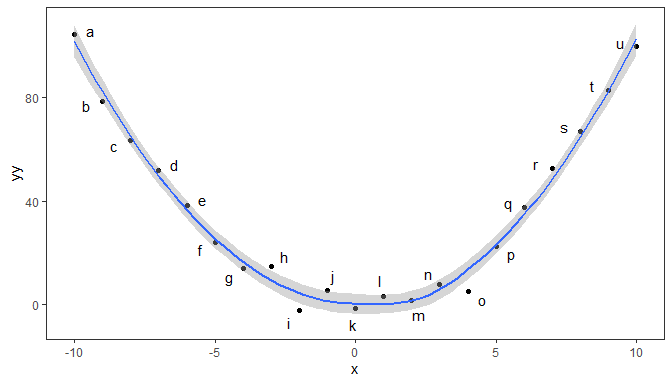

```r
ggplot(df, aes(x, yy, label = l)) +
  geom_point() +
  stat_smooth(formula = y ~ x, method = "loess") +
  geom_text(aes(y = yy, label = l),
            position = position_nudge_line(x = 0.6,
                                           y = 6,
                                           direction = "split"))
```

When fitting a polynomial, `"lm"` should be the argument passed to `method` and a model formula preferably based on `poly()`, setting `raw = TRUE`, as argument to `formula`. *Currently no other methods are implemented in* `position_nudge_line()`.

```r
ggplot(df, aes(x, yy, label = l)) +
  geom_point() +
  stat_smooth(method = "lm", formula = y ~ poly(x, 2, raw = TRUE)) +
  geom_text(aes(y = yy, label = l),
            position = position_nudge_line(method = "lm",
                                           x = 0.6,
                                           y = 6,
                                           formula = y ~ poly(x, 2, raw = TRUE),
                                           direction = "split"))
```

Grouping is supported.

```r
df <- data.frame(x = rep(1:10, 2),
                 y = c(1:10, 10:1),
                 group = rep(c("a", "b"), c(10, 10)),
                 l = "+")
```

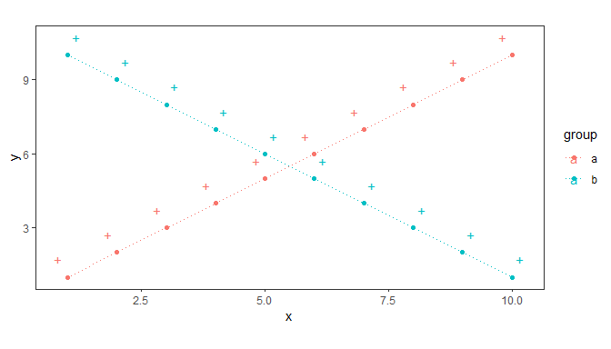

```r
ggplot(df, aes(x, y, label = l, color = group)) +
  geom_line(linetype = "dotted") +
  geom_point() +
  geom_text(position = position_nudge_line(x = 0.25, y = 1)) +
  coord_equal(ratio = 0.5)
```

One needs to ensure that grouping is in effect in the geoms with nudging.

```r
ggplot(df, aes(x, y, label = l, color = group, group = group)) +
  geom_line(linetype = "dotted") +
  geom_text() +
  geom_text(color = "red",
            position = position_nudge_line(x = 1, y = 1)) +
  geom_text(color = "blue",
            position = position_nudge_line(x = -1, y = -1)) +
  coord_equal()
```

Facets are also supported.

```r
ggplot(df, aes(x, y, label = l)) +
  geom_line(linetype = "dotted") +
  geom_point() +
  geom_text(position = position_nudge_line(x = 1, y = 1),
            color = "red") +
  geom_text(position = position_nudge_line(x = -1, y = -1),
            color = "blue") +
  facet_wrap(~group) +
  coord_equal(ratio = 1)
```

## Appendix A: More on density filtering

We define a function to simplify the generation of random data sets based on different probability distributions.

```r
make_data_tbl <- function(nrow = 100, rfun = rnorm, ...) {
  if (nrow %% 2) {
    nrow <- nrow + 1
  }

  set.seed(1001)

  tibble::tibble(
    x = rfun(nrow, ...),
    y = rfun(nrow, ...),
    group = rep(c("A", "B"), c(nrow / 2, nrow / 2))
  )
}
```

In all the examples in this vignette we use colors to demonstrate which data points are selected, but any other suitable aesthetic and discrete scale can be used instead. With `keep.sparse = FALSE` we keep 1/3 of the observations in the denser region of the plot. Although here we first plot all data points and later overplot the selected ones this is not necessary.

```r
ggplot(data = make_data_tbl(300), aes(x, y)) +
  geom_point() +
  stat_dens2d_filter(colour = "red",
                     keep.sparse = FALSE,
                     keep.fraction = 1/3)
```

Here we highlight the observations split in three group equal groups, each of a different density of observations.

```r
ggplot(data = make_data_tbl(300), aes(x, y)) +
  geom_point() +
  stat_dens2d_filter(colour = "red",
                     keep.sparse = FALSE,
                     keep.fraction = 1/3)+
  stat_dens2d_filter(colour = "blue",
                     keep.fraction = 1/3)
```

The algorithm seems to work well also with other distributions, in this example the uniform distribution.

```r
ggplot(data = make_data_tbl(300, rfun = runif), aes(x, y)) +
  geom_point() +
  stat_dens2d_filter(colour = "red", keep.fraction = 1/2)
```

One example with the gamma distribution, which is asymmetric.

```r
ggplot(data = make_data_tbl(300, rfun = rgamma, shape = 2),
       aes(x, y)) +
  geom_point() +
  stat_dens2d_filter(colour = "red", keep.fraction = 1/3)
```

## Appendix B: try_tibble()

### Time series

Several different formats for storing time series data are used in R. Here we use in the examples objects of class `ts` but several other classes are supported as `try.xts()` is used internally. The first example is a quarterly series.

```r
class(austres)
```

```
## [1] "ts"
```

```r
austres.df <- try_tibble(austres)
class(austres.df)
```

```
## [1] "tbl_df"     "tbl"        "data.frame"
```

```r
head(austres.df, 4)
```

```
## # A tibble: 4 x 2
##   time            x
##   <date>      <dbl>
## 1 1971-04-01 13067.
## 2 1971-07-01 13130.
## 3 1971-10-01 13198.
## 4 1972-01-01 13254.
```

The next chunk demonstrates that numeric times are expressed as decimal years in the returned data frame.

```r
austres.df <- try_tibble(austres, as.numeric = TRUE)
head(austres.df, 4)
```

```
## # A tibble: 4 x 2
##    time      x
##   <dbl>  <dbl>
## 1 1971. 13067.
## 2 1971. 13130.
## 3 1972. 13198.
## 4 1972  13254.
```

This second example is for a series of yearly values.

```r
class(lynx)
lynx.df <- try_tibble(lynx)
class(lynx.df)
head(lynx.df, 3)
```

```r
lynx.df <- try_tibble(lynx, "year")
head(lynx.df, 3)
```

```
## # A tibble: 3 x 2
##   time           x
##   <date>     <dbl>
## 1 1821-01-01   269
## 2 1822-01-01   321
## 3 1823-01-01   585
```

```r
lynx_n.df <- try_tibble(lynx, "year", as.numeric = TRUE)
lapply(lynx_n.df, "class")
head(lynx_n.df, 3)
```

### Other classes

`try_tibble()` attempts to handle gracefully objects that are not time series.

```r
try_tibble(1:5)
```

```r
try_tibble(letters[1:5])
```

```r
try_tibble(factor(letters[1:5]))
```

```r
try_tibble(list(x = rep(1,5), y = 1:5))
```

```r
try_tibble(data.frame(x = rep(1,5), y = 1:5))
```

```r
try_tibble(matrix(1:10, ncol = 2))
```